# Stat. 651 Section 1 or 2: Homework 2

**Prof. Eric A. Suess**

So how should you complete your homework for this class?

- First thing to do is type all of your information about the problems you complete in the text part of your R Notebook.
- Second thing to do is type all of your R code into R chunks that can be run.
- If you load the tidyverse in an R Notebook chunk, be sure to include the “message = FALSE” in the {r}, so {r message = FALSE}.
- Last thing is to spell check your R Notebook. Edit > Check Spelling… or hit the F7 key.

Using an R Notebook produce your solutions to the following questions. Start by making an R Notebook with file name Lastname_Firstname_Stat651_hw2.Rmd. Then knit the .Rmd file to either Lastname_Firstname_Stat651_hw2.docx. Use your own last name and first name in the filename. At the top of your first page you should include Name, Class, Section, and homework assignment.

The header of your R Notebooks should include

title: “Stat. 651 Homework 2”

author: “Your name”

date: “October 31, 2022”

Upload one file to Blackboard.

Instructions: Put all of your R code, .docx, .html, etc. files, and Tableau files into one directory. Zip the directory into a .zip file and then upload it to Blackboard. Make sure the directory has your name it it. Directory name lastname_firstname_Stat651_homework02.

Homework 2:

```
- Watch the The beauty of data visualization - David McCandless
- Make the plots for the CIACountries data in Tableau.

- Chapter 14 Exercises Problem 3, Problem 4, Problem 6, Problem 7, Problem 8
```

# In Tableau

Here is the link to my [CIACountries Dashboard](https://public.tableau.com/views/mapwithdots_16668457760050/Sheet1?:language=en-US&:display_count=n&:origin=viz_share_link)

The pacman package in R can be used to load many packages at once using the p_load() function.

```r
library(pacman)

p_load(tidyverse, macleish, lubridate, mdsr, DT, palmerpenguins)
```

# Chapter 14 Problem 3

Note that a second date frame can be used to add the seasons to the plot.

```r
whately_2015 %>% select(when, temperature)
```

| when | temperature |
| --- | --- |
| 2015-01-01 00:00:00 | -9.320 |
| 2015-01-01 00:10:00 | -9.460 |
| 2015-01-01 00:20:00 | -9.440 |
| 2015-01-01 00:30:00 | -9.300 |
| 2015-01-01 00:40:00 | -9.320 |
| 2015-01-01 00:50:00 | -9.340 |
| 2015-01-01 01:00:00 | -9.300 |
| 2015-01-01 01:10:00 | -9.100 |
| 2015-01-01 01:20:00 | -9.070 |
| 2015-01-01 01:30:00 | -8.990 |

[output cut: 990 more lines]

```r
seasons_2015 <- tibble(
    when = (ymd(c("2015 March 20", "2015 June 21", "2015 September 23", "2015 December 21"))),
    season = c("Spring", "Summer", "Fall", "Winter")
)
seasons_2015
```

| when | season |
| --- | --- |
| 2015-03-20 | Spring |
| 2015-06-21 | Summer |
| 2015-09-23 | Fall |
| 2015-12-21 | Winter |

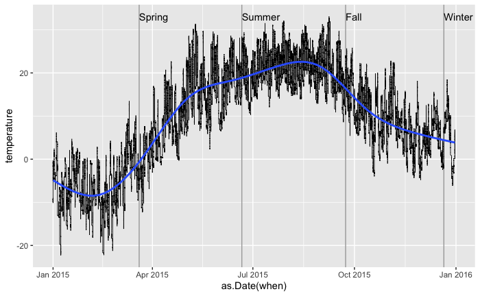

```r
whately_plot <- whately_2015 %>% ggplot(aes(y = temperature, x = as.Date(when))) +
  geom_vline(data = seasons_2015, color = "darkgray", aes( xintercept = as.Date(when) ) ) +
  geom_text(data = seasons_2015, aes(y = 33, label = season, hjust = "left")) +
  geom_line(size = 0.3) +
  geom_smooth() +
  scale_x_date()
whately_plot
```